# Task: Augmentation

**Student Name:** Sébastien Bagdasarianz  
**Country:** Colombia  
**Semester term:** HS26

```python
from pathlib import Path

DATA_DIR = Path("data")
```

## Day 1 – Data & Domain

### Use Case

*Focus: domain and application context*

*Guidelines: Describe a realistic and application scenario in which the targeted signal or image processing task plays a critical role. Clearly specify the domain, the system in which the signal or image is measured or processed, and the practical objective of this system. Explain who relies on the signal or image and for what type of decision-making or analysis. Briefly explain why this use case is particularly relevant for your selected country. Justify your choice based on economic, environmental, societal, technological, or geographic factors. Write your use case as a short, focused paragraph (1-3 sentences).*

In the context of citizen-science biodiversity monitoring and wildlife-trafficking reports in Colombia, images of parrots are taken by members of the public with smartphone cameras and uploaded to platforms with automatic species recognition (e.g. iNaturalist, eBird). These images are used by ornithologists and environmental authorities to map urban parrot occurrences and to flag native Amazon parrots kept as pets, which is illegal for wild-caught native birds. This use case is particularly relevant for Colombia because it has the richest avifauna in the world (more than 1,900 bird species), and native parrots such as the Yellow-crowned Amazon are commonly taken from the wild and kept in households, including in Cartagena.

### Problem Statement

*Focus: technical vulnerability*

*Guidelines: Formulate a clear and technically precise problem statement. Explicitly refer to the signal or image processing task under investigation and identify the specific technical risk or limitation associated with it. Describe what may go wrong if an approach, method, or parameter is chosen or applied inadequately. Explain why this technical vulnerability is critical within your selected use case. Write your problem statement as a short, focused paragraph (1–3 sentences).*

This project addresses the problem of making automatic parrot species recognition robust to the degradations of hand-held smartphone photos taken in Colombian streets. If the training images are only sharp, well-exposed photos, motion blur (bird or hand moving during the exposure) and sensor noise (small phone sensor in shaded streets) can soften or mask the yellow crown patch that separates *Amazona ochrocephala* from other green Amazon parrots, leading to misidentified or unidentified reports. Preserving the colour boundary of the crown patch is essential for reliable species identification in this use case.

### Experimental Objective

*Focus: investigation goal at the conceptual level.*

*Guidelines: Clearly state what you intend to understand or demonstrate in relation to your use case. Formulate your objective at a conceptual level without describing specific methods, algorithms, or implementation details. The objective should explain what aspect of signal or image behavior you aim to analyze and why this analysis is important for your application. Write your objective as a short, focused paragraph (1–2 sentences).*

The objective of this project is to investigate how realistic motion blur and sensor noise change the appearance of the diagnostic crown patch of an Amazon parrot, in order to understand which degradation levels still keep the species feature recognisable and are therefore meaningful as training augmentations.

### Data Definition, Source, and Visualization

*Focus: data characteristics, data source, and visual inspection.*

*Guidelines: Describe a representative one-dimensional signal or two-dimensional image suitable for your use case. Briefly explain its physical origin, how it is acquired, its unit of measurement, and the key characteristics relevant to your investigation. Specify the exact dataset name and repository or institution from which the data originate, and justify why this source is appropriate. Write 3-5 concise sentences.*

The selected image is an own photograph of a Yellow-crowned Amazon (*Amazona ochrocephala*, identified by plumage, not expert-verified) perched on an orange wooden stand in front of a turquoise house wall with the address tile "10B-34" in Cartagena, Bolívar. It was taken on 11 February 2023 with an iPhone 12 (wide camera, focal length 4.2 mm), converted from HEIC to JPEG (quality 95) and has 3024 × 4032 px, 8-bit sRGB; intensities are normalised to [0, 1] (dimensionless). Its relevant characteristics are the sharp, saturated yellow crown patch on a green head, the fine feather texture, and the low existing noise level, which together make it a clean reference for controlled degradation. The data are own work (Sébastien Bagdasarianz, CC BY 4.0) and are appropriate because they show exactly the type of street-level phone photo of a Colombian parrot that citizen-science platforms receive, with the diagnostic feature clearly visible.

*Guideline: Visualize a representative excerpt of your signal or a relevant region of your image. If the data are audio-based, additionally provide a playable audio segment. All visualizations must include clearly labeled axes and the correct units.*

```
File: parrot_IMG_2719.jpg | Camera: Apple iPhone 12 | Taken: 2023:02:11 12:08:40 (local time, Cartagena)
Image size: 3024 x 4032 px, 3 channels, intensities normalized to [0, 1]
Crown patch: 12173 px, bounding box 158 x 114 px (width x height)
Luminance: crown 0.798, surrounding green plumage 0.542, step dY = 0.255
High-pass std on flat wall (upper bound of existing noise): 0.0140
```

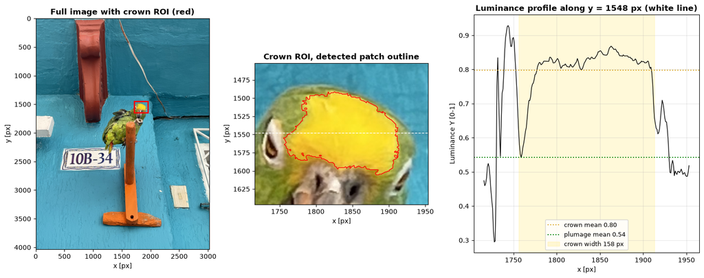

```python
import matplotlib.pyplot as plt
import numpy as np
from matplotlib.patches import Rectangle
from PIL import Image, ImageOps
from scipy import ndimage as ndi

image_path = DATA_DIR / "parrot_IMG_2719.jpg"
raw = Image.open(image_path)
exif = raw.getexif()
parrot = np.asarray(ImageOps.exif_transpose(raw).convert("RGB"), dtype=float) / 255.0
height, width, _ = parrot.shape


def luminance(rgb):
    return rgb @ np.array([0.299, 0.587, 0.114])


# Crown = saturated yellow: high red and green, low blue (thresholds read from the RGB values of the patch).
red, green, blue = parrot[..., 0], parrot[..., 1], parrot[..., 2]
yellow = (red > 0.75) & (green > 0.65) & (blue < 0.35) & (red > 0.95 * green)
labels, n_labels = ndi.label(yellow)
crown_label = np.argmax(ndi.sum(yellow, labels, range(1, n_labels + 1))) + 1
crown_mask = labels == crown_label
rows, cols = np.nonzero(crown_mask)
crown_width = cols.max() - cols.min() + 1
crown_height = rows.max() - rows.min() + 1

ROI_MARGIN = 40
roi = (rows.min() - ROI_MARGIN, rows.max() + ROI_MARGIN + 1, cols.min() - ROI_MARGIN, cols.max() + ROI_MARGIN + 1)

plumage = (green > 1.05 * red) & (green > 1.3 * blue) & (green > 0.35)
ring = ndi.binary_dilation(crown_mask, iterations=40) & ~ndi.binary_dilation(crown_mask, iterations=10) & plumage
lum = luminance(parrot)
crown_lum = lum[crown_mask].mean()
plumage_lum = lum[ring].mean()
delta_lum = crown_lum - plumage_lum

wall = lum[300:600, 2400:2800]
noise_estimate = (wall - ndi.gaussian_filter(wall, 3)).std()

print(f"File: {image_path.name} | Camera: {exif.get(271)} {exif.get(272)} | Taken: {exif.get(306)} (local time, Cartagena)")
print(f"Image size: {width} x {height} px, 3 channels, intensities normalized to [0, 1]")
print(f"Crown patch: {crown_mask.sum()} px, bounding box {crown_width} x {crown_height} px (width x height)")
print(f"Luminance: crown {crown_lum:.3f}, surrounding green plumage {plumage_lum:.3f}, step dY = {delta_lum:.3f}")
print(f"High-pass std on flat wall (upper bound of existing noise): {noise_estimate:.4f}")

centre_row = int(rows.mean())
profile_cols = np.arange(roi[2], roi[3])

fig, axes = plt.subplots(1, 3, figsize=(15, 6), gridspec_kw={"width_ratios": [1, 1, 1.3]})
axes[0].imshow(parrot)
axes[0].add_patch(Rectangle((roi[2], roi[0]), roi[3] - roi[2], roi[1] - roi[0], fill=False, edgecolor="red", linewidth=2))
axes[0].set_title("Full image with crown ROI (red)", fontweight="bold")
axes[0].set_xlabel("x [px]")
axes[0].set_ylabel("y [px]")
axes[1].imshow(parrot[roi[0]:roi[1], roi[2]:roi[3]], extent=(roi[2], roi[3], roi[1], roi[0]))
axes[1].contour(np.arange(roi[2], roi[3]), np.arange(roi[0], roi[1]), crown_mask[roi[0]:roi[1], roi[2]:roi[3]], levels=[0.5], colors="red", linewidths=1)
axes[1].axhline(centre_row, color="white", linestyle="--", linewidth=1)
axes[1].set_title("Crown ROI, detected patch outline", fontweight="bold")
axes[1].set_xlabel("x [px]")
axes[1].set_ylabel("y [px]")
axes[2].plot(profile_cols, lum[centre_row, roi[2]:roi[3]], color="black", linewidth=1)
axes[2].axhline(crown_lum, color="goldenrod", linestyle=":", label=f"crown mean {crown_lum:.2f}")
axes[2].axhline(plumage_lum, color="green", linestyle=":", label=f"plumage mean {plumage_lum:.2f}")
axes[2].axvspan(cols.min(), cols.max(), color="gold", alpha=0.15, label=f"crown width {crown_width} px")
axes[2].set_title(f"Luminance profile along y = {centre_row} px (white line)", fontweight="bold")
axes[2].set_xlabel("x [px]")
axes[2].set_ylabel("Luminance Y [0-1]")
axes[2].legend(loc="lower center", fontsize=9)
axes[2].grid(alpha=0.3)
plt.tight_layout()
plt.show()
```

### Observations

> The visualization shows the full photo and the crown region of interest (ROI, 238 × 194 px, crown bounding box plus a 40 px margin). The automatically detected yellow patch covers 12,173 px with a bounding box of 158 × 114 px. Along the horizontal profile through the crown centre (y = 1548 px) the luminance rises from about 0.54 on the green plumage to a plateau of about 0.80 on the crown, i.e. a step of $\Delta Y = 0.255$ over roughly 10–15 px on each side. The high-pass standard deviation on a flat wall patch is 0.014, so the existing noise is small compared with this step. This region was selected because the crown boundary is the visual feature that a recognition model must preserve to identify the species, and its width and contrast define the scale of the augmentations on Day 2.

### Task-Specific Answers: Structure of Interest and Augmentation Objective

- **Relevant visual structures:** strong colour edges (yellow crown vs. green head, bird vs. turquoise wall), fine feather textures on the head and wing, the beak and eye ring as small high-contrast objects, and the rough plaster texture of the wall.
- **Identified structure:** the yellow crown patch and its boundary to the green plumage (red outline above). It is about 158 px wide, has a nearly flat interior (plateau around $Y \approx 0.8$) and a sharp transition to $Y \approx 0.54$.
- **How the challenge manifests in this structure:** motion blur mixes yellow and green pixels across the crown boundary, so the patch looks narrower, softer and more yellow-green; once the blur length approaches the crown width, no pure yellow core remains. Sensor noise adds random fluctuations on top of the 0.255 luminance step, which lowers the contrast-to-noise ratio and makes the patch outline grainy and less distinct.
- **Objective of augmentation:** simulate realistic, controlled smartphone degradations of the crown patch to increase the variability of training data, while knowing at which strength the diagnostic feature is still preserved.

## Day 2 – Methodological Design

Plan two photometric augmentations for the same parrot photo, motion blur and additive sensor noise, with parameters derived from the crown width and contrast measured on Day 1. Geometric transformations are excluded.

*Guidelines: Establish the theoretical and methodological foundation for your selected signal or image processing operation in direct alignment with the country-specific use case defined previously. Formally state the relevant theoretical principle and explain its assumptions, validity conditions, and domain-specific applicability. Select and justify concrete methods and parameter values appropriate for your one-dimensional signal or two-dimensional image data, explaining why these choices fit the defined analytical objective. Derive necessary quantities mathematically where applicable, documenting each step with explicit assumptions and consistent units (temporal, spatial, or frequency units as relevant). Specify and justify the experimental design to be executed on the next day: define the parameters to vary, the control/baseline configuration, and the structured parameter sweep (ranges and step sizes). Theoretically predict the expected qualitative effects of these variations on the signal or image and identify likely failure modes (e.g., aliasing, instability, sensitivity to noise, loss of detail). Discuss methodological limitations, idealizations, and potential sources of misinterpretation. No simulations, visualizations, or experimental demonstrations should be included.*

### Theoretical Foundation and Method Choice

Motion blur is modelled as a linear, shift-invariant convolution of the sharp image $f$ with a line point-spread function $h_L$ of length $L$ pixels, followed by additive sensor noise: $g = f * h_L + n$, with $h_L(x, y) = 1/L$ for $|x| \le (L-1)/2,\ y = 0$ and $n \sim \mathcal{N}(0, \sigma^2)$ independently per pixel and colour channel. In the frequency domain the line PSF is a sinc low-pass along the motion direction, so structures narrower than about $L$ pixels are averaged out, while the crown patch survives as long as $L$ stays below its width $W$. The model assumes constant motion during the exposure and signal-independent noise. These two augmentations are chosen because they correspond to the two dominant failure sources of hand-held photos of a moving bird; a Gaussian (defocus) blur was rejected because phone autofocus rarely misses a well-lit subject at this distance, whereas bird and hand motion are directional.

### Parameter Definition and Mathematical Specification

Data-inherent parameters (Day 1): image 3024 × 4032 px, crown width $W = 158$ px, crown–plumage luminance step $\Delta Y = 0.255$, existing noise $\le 0.014$. Method parameters: blur length $L$ (px, horizontal, angle 0°) and noise standard deviation $\sigma$ (dimensionless intensity, per channel). $L$ is defined relative to the crown: $L = 0.25\,W \approx 39$ px leaves an unblurred core of $W - L = 119$ px, while $L = 0.75\,W \approx 119$ px leaves only a 39 px core, so the patch is almost fully mixed with green (both rounded to the nearest odd value so the kernel has a centre pixel). $\sigma$ is defined relative to the step that carries the information: $\sigma = 0.10\,\Delta Y \approx 0.026$ gives a contrast-to-noise ratio $\Delta Y/\sigma = 10$, and $\sigma = 0.30\,\Delta Y \approx 0.077$ gives $\Delta Y/\sigma \approx 3.3$. Blur is applied before noise, because the motion is integrated optically before the sensor adds noise; values are clipped to [0, 1] and the random seed is fixed (42).

### Experimental Design for Next Days

The reference is the original image. The baseline configuration A is a mild, realistic degradation ($L = 39$ px, $\sigma = 0.026$); configuration B increases only the blur ($L = 119$ px, $\sigma = 0.026$) and configuration C increases only the noise ($L = 39$ px, $\sigma = 0.077$), so each variation changes exactly one parameter relative to the baseline. It is expected that B widens the crown boundary transition from a few pixels to about 119 px and turns the patch into a yellow-green gradient, while C keeps the patch position but makes its interior and outline grainy. Day 3 implements these three configurations and Day 4 quantifies their effect within the crown ROI.

### Methodological Limitations and Risk Factors

The model assumes uniform, straight motion and a spatially constant PSF, whereas a real bird moves its head independently of the body and the hand may rotate; it also assumes independent Gaussian noise, while real phone noise is signal-dependent and spatially correlated by demosaicking and HEIC/JPEG compression. The augmentations are applied to an already processed (denoised, compressed) photo, and only one image, one motion direction and one noise seed are used, so the results describe this crown, not every Amazon photo.

## Day 3 – Implementation

Implement the two augmentations as small functions, verify them on a synthetic test image with known answers, and then apply the three predefined configurations from Day 2 to the parrot photo. Evaluation follows on Day 4.

### Functional Check on a Synthetic Test Image

The test image is a 100 × 100 px yellow square on a green background. A correct horizontal box blur must keep the mean brightness (kernel sum = 1) and turn each vertical edge into a linear ramp exactly $L$ pixels wide; the added noise must have the requested standard deviation. These three properties are checked with `assert` statements.

```
Kernel sum = 1.000 (brightness preserved)
Edge ramp width after blur = 25 px (expected L = 25 px)
Measured noise std = 0.0496 (expected sigma = 0.05)
```

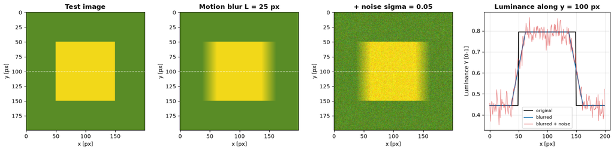

```python
from skimage.metrics import structural_similarity

SEED = 42
BLUR_ANGLE_DEG = 0


def odd(value):
    """Nearest odd integer, so the line kernel has a centre pixel and causes no half-pixel shift."""
    return int(2 * round((value - 1) / 2) + 1)


def motion_blur_kernel(length):
    """Uniform horizontal line PSF: the scene moves `length` px during the exposure."""
    return np.full((1, length), 1.0 / length)


def apply_motion_blur(rgb, length):
    kernel = motion_blur_kernel(length)
    return np.stack([ndi.convolve(rgb[..., c], kernel, mode="reflect") for c in range(3)], axis=-1)


def add_sensor_noise(rgb, sigma, seed=SEED):
    rng = np.random.default_rng(seed)
    return np.clip(rgb + rng.normal(0.0, sigma, rgb.shape), 0.0, 1.0)


def augment(rgb, length, sigma):
    """Blur first, then noise: motion is integrated optically before the sensor adds noise."""
    return add_sensor_noise(apply_motion_blur(rgb, length), sigma)


test = np.zeros((200, 200, 3))
test[...] = (0.35, 0.55, 0.15)
test[50:150, 50:150] = (0.95, 0.85, 0.10)
test_length, test_sigma = 25, 0.05
test_blur = apply_motion_blur(test, test_length)
test_noisy = add_sensor_noise(test_blur, test_sigma)

row = luminance(test_blur)[100]
ramp_width = int(np.sum((row > row.min() + 1e-6) & (row < row.max() - 1e-6)) / 2) + 1
measured_sigma = (test_noisy - test_blur)[:40, :40].std()
assert np.isclose(motion_blur_kernel(test_length).sum(), 1.0)
assert np.allclose(test_blur.mean(axis=(0, 1)), test.mean(axis=(0, 1)), atol=1e-3)
assert ramp_width == test_length
assert abs(measured_sigma - test_sigma) < 0.005
print(f"Kernel sum = {motion_blur_kernel(test_length).sum():.3f} (brightness preserved)")
print(f"Edge ramp width after blur = {ramp_width} px (expected L = {test_length} px)")
print(f"Measured noise std = {measured_sigma:.4f} (expected sigma = {test_sigma})")

fig, axes = plt.subplots(1, 4, figsize=(16, 4))
for ax, img, title in zip(axes[:3], [test, test_blur, test_noisy], ["Test image", f"Motion blur L = {test_length} px", f"+ noise sigma = {test_sigma}"]):
    ax.imshow(img)
    ax.axhline(100, color="white", linestyle="--", linewidth=1)
    ax.set_title(title, fontweight="bold")
    ax.set_xlabel("x [px]")
    ax.set_ylabel("y [px]")
axes[3].plot(luminance(test)[100], label="original", color="black")
axes[3].plot(luminance(test_blur)[100], label="blurred", color="tab:blue")
axes[3].plot(luminance(test_noisy)[100], label="blurred + noise", color="tab:red", alpha=0.6, linewidth=0.8)
axes[3].set_title("Luminance along y = 100 px", fontweight="bold")
axes[3].set_xlabel("x [px]")
axes[3].set_ylabel("Luminance Y [0-1]")
axes[3].legend(fontsize=8)
axes[3].grid(alpha=0.3)
plt.tight_layout()
plt.show()
```

### Application to the Parrot Image

The configurations are computed from the Day 1 measurements (`crown_width`, `delta_lum`) instead of being typed in by hand, so each parameter is traceable to the image. For each configuration the intermediate result after step 1 (blur) and the final result after step 2 (noise) are shown in the crown ROI, together with the luminance profile through the crown centre.

```
A (baseline)      L =  39 px (0.25 x crown width), sigma = 0.026 (0.10 x dY), angle = 0 deg, seed = 42
B (strong blur)   L = 119 px (0.75 x crown width), sigma = 0.026 (0.10 x dY), angle = 0 deg, seed = 42
C (strong noise)  L =  39 px (0.25 x crown width), sigma = 0.077 (0.30 x dY), angle = 0 deg, seed = 42
```

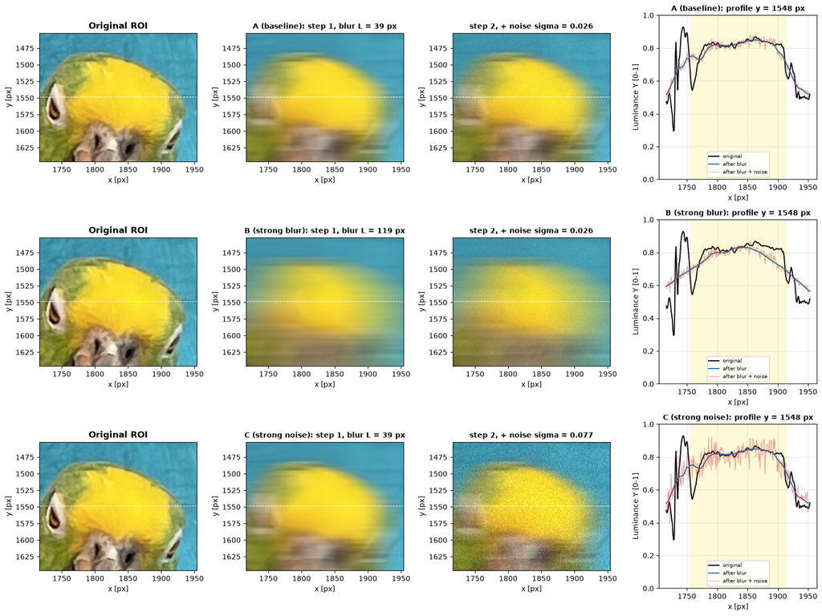

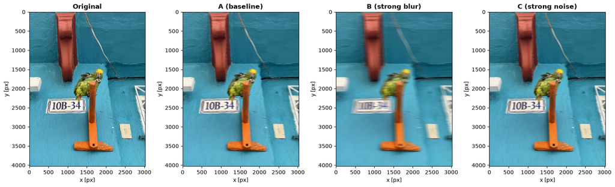

```python
CONFIGS = {
    "A (baseline)": {"length": odd(0.25 * crown_width), "sigma": round(0.10 * delta_lum, 3)},
    "B (strong blur)": {"length": odd(0.75 * crown_width), "sigma": round(0.10 * delta_lum, 3)},
    "C (strong noise)": {"length": odd(0.25 * crown_width), "sigma": round(0.30 * delta_lum, 3)},
}
for name, cfg in CONFIGS.items():
    print(f"{name:17s} L = {cfg['length']:3d} px ({cfg['length'] / crown_width:.2f} x crown width), "
          f"sigma = {cfg['sigma']:.3f} ({cfg['sigma'] / delta_lum:.2f} x dY), angle = {BLUR_ANGLE_DEG} deg, seed = {SEED}")

stages = {}
for name, cfg in CONFIGS.items():
    blurred = apply_motion_blur(parrot, cfg["length"])
    stages[name] = {"blurred": blurred, "augmented": add_sensor_noise(blurred, cfg["sigma"])}

r0, r1, c0, c1 = roi
fig, axes = plt.subplots(3, 4, figsize=(16, 12))
for i, (name, stage) in enumerate(stages.items()):
    cfg = CONFIGS[name]
    axes[i, 0].imshow(parrot[r0:r1, c0:c1], extent=(c0, c1, r1, r0))
    axes[i, 0].set_title("Original ROI", fontweight="bold")
    axes[i, 1].imshow(stage["blurred"][r0:r1, c0:c1], extent=(c0, c1, r1, r0))
    axes[i, 1].set_title(f"{name}: step 1, blur L = {cfg['length']} px", fontweight="bold", fontsize=10)
    axes[i, 2].imshow(stage["augmented"][r0:r1, c0:c1], extent=(c0, c1, r1, r0))
    axes[i, 2].set_title(f"step 2, + noise sigma = {cfg['sigma']}", fontweight="bold", fontsize=10)
    for ax in axes[i, :3]:
        ax.axhline(centre_row, color="white", linestyle="--", linewidth=0.8)
        ax.set_xlabel("x [px]")
        ax.set_ylabel("y [px]")
    axes[i, 3].plot(profile_cols, lum[centre_row, c0:c1], color="black", label="original")
    axes[i, 3].plot(profile_cols, luminance(stage["blurred"])[centre_row, c0:c1], color="tab:blue", label="after blur")
    axes[i, 3].plot(profile_cols, luminance(stage["augmented"])[centre_row, c0:c1], color="tab:red", alpha=0.5, linewidth=0.7, label="after blur + noise")
    axes[i, 3].axvspan(cols.min(), cols.max(), color="gold", alpha=0.15)
    axes[i, 3].set_ylim(0, 1)
    axes[i, 3].set_title(f"{name}: profile y = {centre_row} px", fontweight="bold", fontsize=10)
    axes[i, 3].set_xlabel("x [px]")
    axes[i, 3].set_ylabel("Luminance Y [0-1]")
    axes[i, 3].legend(fontsize=7, loc="lower center")
    axes[i, 3].grid(alpha=0.3)
plt.tight_layout()
plt.show()

fig, axes = plt.subplots(1, 4, figsize=(16, 5.5))
axes[0].imshow(parrot)
axes[0].set_title("Original", fontweight="bold")
for ax, (name, stage) in zip(axes[1:], stages.items()):
    ax.imshow(stage["augmented"])
    ax.set_title(f"{name}", fontweight="bold")
for ax in axes:
    ax.set_xlabel("x [px]")
    ax.set_ylabel("y [px]")
plt.tight_layout()
plt.show()
```

## Day 4 – Evaluation

The same metric, region and reference are applied to every configuration. Only the crown ROI is evaluated, because the use case depends on the crown patch, not on the wall or perch.

### Evaluation Approach Definition

The selected metric is the Structural Similarity Index (SSIM) between the luminance of the original and the augmented image, averaged over the crown ROI: $$\mathrm{SSIM}(x, y) = \frac{(2\mu_x\mu_y + C_1)(2\sigma_{xy} + C_2)}{(\mu_x^2 + \mu_y^2 + C_1)(\sigma_x^2 + \sigma_y^2 + C_2)}$$ computed in Gaussian windows ($\sigma_w = 1.5$ px), with $C_1 = (0.01)^2$, $C_2 = (0.03)^2$ and data range 1; 1 means identical, 0 means no structural similarity. It is chosen because the objective is to preserve the appearance of the crown patch, and SSIM compares exactly the local luminance, contrast and structure that blur (softened boundary) and noise (random fluctuations) change. Its validity requires pixel-aligned images, which holds because no geometric transformation is applied.

### Evaluation Comparison Execution

The influence of the blur length $L$ and the noise level $\sigma$ was evaluated with SSIM in the crown ROI. Both parameters are essential for the use case because they control whether the crown boundary that identifies the species remains visible. Configuration A is the baseline; B varies only $L$ and C varies only $\sigma$, and the relative change in SSIM is computed with respect to A. The local SSIM maps show where in the ROI the similarity is lost.

```
SSIM on luminance, crown ROI 238 x 194 px (reference: original image, SSIM = 1)
Configuration       L [px]   sigma    SSIM  vs. baseline
A (baseline)            39   0.026  0.5664         +0.0 %
B (strong blur)        119   0.026  0.5269         -7.0 %
C (strong noise)        39   0.077  0.2641        -53.4 %
```

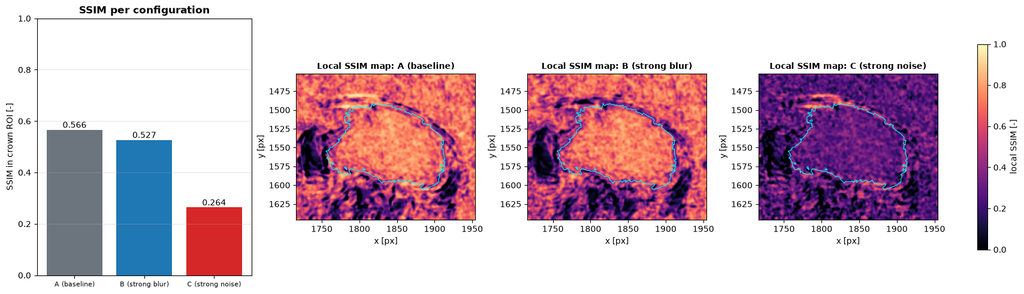

```python
reference_roi = lum[r0:r1, c0:c1]
results = {}
ssim_maps = {}
for name, stage in stages.items():
    score, ssim_map = structural_similarity(
        reference_roi,
        luminance(stage["augmented"])[r0:r1, c0:c1],
        data_range=1.0,
        gaussian_weights=True,
        sigma=1.5,
        use_sample_covariance=False,
        full=True,
    )
    results[name] = score
    ssim_maps[name] = ssim_map

baseline = results["A (baseline)"]
print(f"SSIM on luminance, crown ROI {c1 - c0} x {r1 - r0} px (reference: original image, SSIM = 1)")
print(f"{'Configuration':18s} {'L [px]':>7s} {'sigma':>7s} {'SSIM':>7s} {'vs. baseline':>13s}")
for name, score in results.items():
    cfg = CONFIGS[name]
    print(f"{name:18s} {cfg['length']:7d} {cfg['sigma']:7.3f} {score:7.4f} {100 * (score - baseline) / baseline:+12.1f} %")

fig, axes = plt.subplots(1, 4, figsize=(17, 4.8), gridspec_kw={"width_ratios": [1.2, 1, 1, 1]}, layout="constrained")
names = list(results)
bars = axes[0].bar(names, [results[n] for n in names], color=["#6c757d", "#1f77b4", "#d62728"])
axes[0].bar_label(bars, fmt="%.3f")
axes[0].set_ylim(0, 1)
axes[0].set_ylabel("SSIM in crown ROI [-]")
axes[0].set_title("SSIM per configuration", fontweight="bold")
axes[0].tick_params(axis="x", labelsize=8)
axes[0].grid(axis="y", alpha=0.3)
for ax, name in zip(axes[1:], names):
    im = ax.imshow(ssim_maps[name], cmap="magma", vmin=0, vmax=1, extent=(c0, c1, r1, r0))
    ax.contour(np.arange(c0, c1), np.arange(r0, r1), crown_mask[r0:r1, c0:c1], levels=[0.5], colors="cyan", linewidths=0.8)
    ax.set_title(f"Local SSIM map: {name}", fontweight="bold", fontsize=10)
    ax.set_xlabel("x [px]")
    ax.set_ylabel("y [px]")
fig.colorbar(im, ax=axes[1:], shrink=0.8, label="local SSIM [-]")
plt.show()
```

### Quantitative Comparison

| Configuration | $L$ [px] | $\sigma$ [-] | SSIM in crown ROI [-] | Relative change to baseline |
| --- | --- | --- | --- | --- |
| Original (reference) | – | – | 1.000 | – |
| **Baseline A:** mild blur + mild noise | 39 | 0.026 | 0.566 | 0 % |
| B: strong blur | 119 | 0.026 | 0.527 | −7.0 % |
| C: strong noise | 39 | 0.077 | 0.264 | −53.4 % |

**Ranking (most to least similar to the original crown):** A > B > C. Tripling the noise level reduces SSIM about 7.6 times more than tripling the blur length.

## Day 5 – Analysis & Communication

*Focus: connect the measured effect of blur and noise on the crown patch to automatic parrot identification from citizen-science photos in Colombia.*

### Observations

SSIM in the crown ROI was 0.566 for the baseline A, 0.527 for strong blur B (−7.0 %) and 0.264 for strong noise C (−53.4 %). Even the mild baseline lost about 43 % similarity to the original.

### Interpretation

Noise lowers SSIM everywhere, because SSIM's structure term divides by local variance and the crown interior is nearly flat. Blur only changes pixels within $L/2$ of an edge, and SSIM's 1.5 px windows see a soft but locally smooth gradient, so B scores almost like A although its crown visibly spreads into the green plumage.

### Discussion and Critical Reflection

For training a recogniser, A is the most suitable augmentation: the crown stays a distinct yellow patch. C, with a contrast-to-noise ratio of 3.3, is too destructive to be labelled reliably. B should not be judged by SSIM alone. With its 39 px core it may already erase the feature that separates *A. ochrocephala* from similar Amazons, which risks training on wrongly labelled examples. SSIM therefore underestimates large-scale blur on flat patches and only partly captures the objective. A boundary-width measure or a classifier test would be needed, using more photos, motion directions and noise seeds.

### Day 5 Reflection and Revisions

Deriving $L$ and $\sigma$ from the crown width and contrast made the augmentation strengths interpretable, but the evaluation showed that a widely used similarity metric can rank a visually destructive blur as almost harmless when the structure of interest is a large flat patch. The main lesson is that the metric's spatial scale must match the scale of the structure, not only the type of degradation.

**Revisions:** none so far.